# Road Accident Hotspot Analysis — Chennai Metropolitan Area

2023–2024 Geospatial & Temporal Analysis

Road Safety Analytics Unit

October 12, 2026

# Executive Summary

High-level findings from 24 months of accident data across the Chennai Metropolitan Area.

3,000

Total Accidents

327

Fatal Accidents

1,075

Serious Injuries

3,300

Total Casualties

# 1 Data Overview

Understanding the dataset before diving into spatial and temporal patterns.

Dataset Summary

| Metric | Value |
| --- | --- |
| Study Period | Jan 2023 – Dec 2024 |
| Total Records | 3,000 |
| Fatal Accidents | 327 (10.9%) |
| Serious Accidents | 1,075 (35.8%) |
| Minor Accidents | 1,598 (53.3%) |
| Total Casualties | 3,300 |
| Geographic Coverage | Chennai Metropolitan Area (~20×20 km) |
| Road Types Covered | Highway, Main Road, Junction, Residential |

The dataset spans two full calendar years (2023–2024), covering 3,000 accident events. Fatal and serious accidents together account for roughly 47% of all incidents, highlighting a significant public safety burden. The spatial spread covers the full Chennai metropolitan footprint, from ECR to GST Road and from the city centre to Sholinganallur.

# 2 Accident Maps

Interactive maps — use the layer control (top-right) to switch between views. Click any marker for details.

## 2.1 All Accidents: Marker Cluster Map

[interactive chart not shown]

The marker cluster map shows all **3,000** recorded accidents across Chennai. Clusters automatically expand as you zoom in. The dense red clusters around the city centre and major arterial roads immediately reveal where accidents concentrate — particularly along Anna Salai, Koyambedu, and the southern OMR/ECR corridors. Click any marker to view individual accident details.

## 2.2 Accident Density: Heatmap

[interactive chart not shown]

The heatmap uses **severity-weighted intensity** (Fatal = 3×, Serious = 2×, Minor = 1×), meaning the red “hottest” zones indicate not just volume but danger. The brightest areas — concentrated near Kathipara, Koyambedu, and OMR Sholinganallur — represent stretches where both accident frequency and severity are highest, demanding the most urgent interventions.

## 2.3 Hotspot Map: Top 5 Danger Zones

[interactive chart not shown]

# 3 Hotspot Analysis

Ranking and profiling the five most dangerous locations in the study area.

## 3.1 Top 5 Hotspot Summary Table

**Top 5 Road Accident Hotspots — Chennai 2023–2024**

Ranked by total accident count; severity score = weighted average (Fatal=3, Serious=2, Minor=1)

| Rank | Location | Total Accidents | Fatal | Serious | Severity Score | Avg Casualties | Peak Hour | Typical Weather | Road Type |
| --- | --- | --- | --- | --- | --- | --- | --- | --- | --- |
| 1 | Anna Salai Junction | 464 | 37 | 177 | 1.54 | 1.03 | 17 | Clear | Main Road |
| 2 | Kathipara Junction | 384 | 48 | 138 | 1.61 | 1.19 | 19 | Clear | Main Road |
| 3 | Koyambedu Flyover | 381 | 34 | 132 | 1.52 | 1.03 | 17 | Clear | Junction |
| 4 | ECR Thiruvanmiyur | 332 | 43 | 114 | 1.60 | 1.10 | 17 | Clear | Main Road |
| 5 | OMR Sholinganallur | 330 | 30 | 111 | 1.52 | 1.03 | 19 | Clear | Main Road |

# 4 Time & Weather Patterns

When and under what conditions do accidents occur most often?

## 4.1 Accidents by Hour of Day

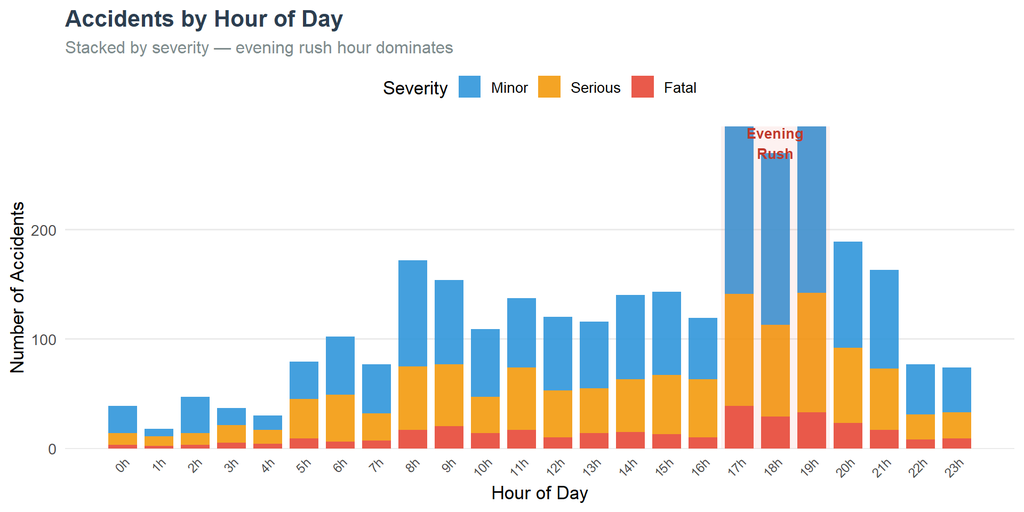

The **5 PM–7 PM evening rush hour** is by far the most dangerous period, accounting for a significantly higher share of both volume and fatal accidents. A secondary morning peak is visible around **8 AM–9 AM**. The pattern is consistent with traffic volume — more vehicles on the road directly translates to more accident opportunities, especially at junctions and arterial intersections where conflicts are highest.

## 4.2 Accidents by Day of Week

[figure not shown]

## 4.3 Accidents by Weather Condition

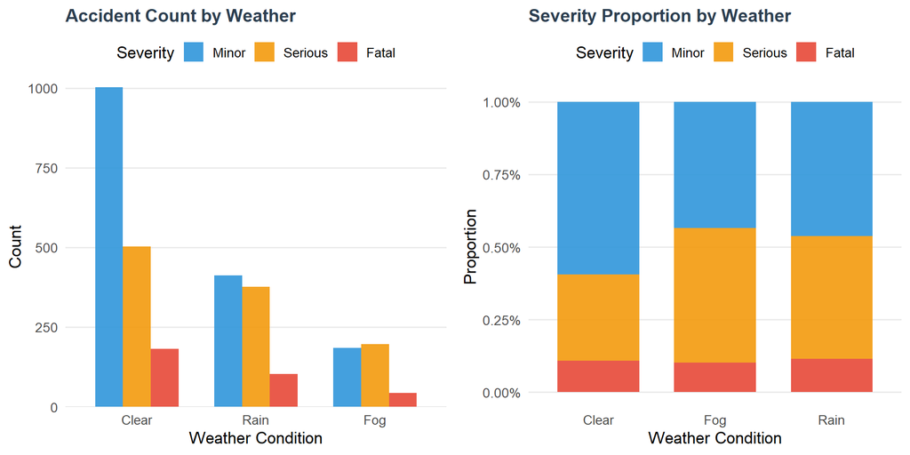

Clear weather has the highest raw accident count simply because it is the most common condition. However, the **proportion chart (right)** tells the real story: **Fog and Rain** conditions produce a noticeably higher share of Serious and Fatal accidents. Reduced visibility and slippery surfaces cause drivers to lose control at higher speeds, dramatically increasing impact severity when collisions occur — particularly on highways and main roads.

## 4.4 Accidents by Road Type

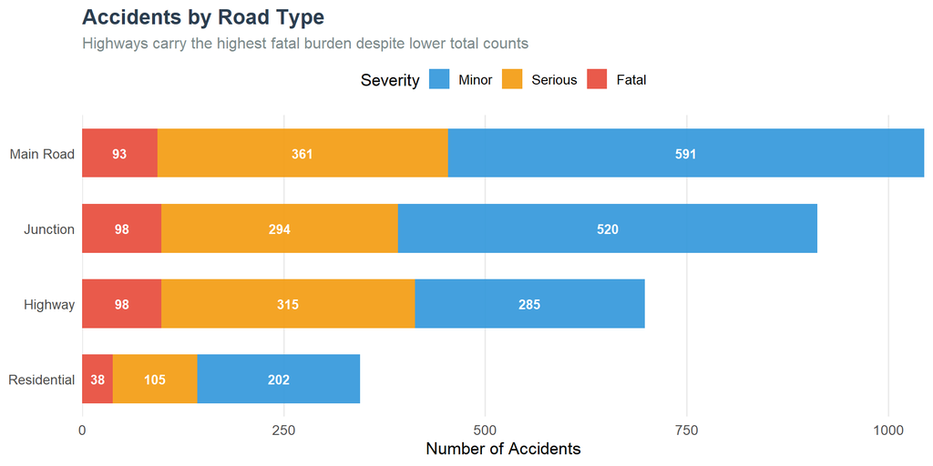

## 4.5 Monthly Accident Trend

[figure not shown]

# 5 Recommendations

Targeted, evidence-based interventions for each of the five identified hotspots.

[output not shown]

[output not shown]

[output not shown]

[output not shown]

[output not shown]

**Implementation Priority:** Interventions at Hotspots #1 and #2 should be treated as **immediate** (< 3 months) given their combined fatality count. Hotspots #3–#5 require engineering assessments and should be actioned within 6–12 months. All hotspots would benefit from an **area-wide 30 km/h zone** during monsoon months and mandatory reflective road markings refreshed annually.

# 6 Appendix: Methodology

## 6.1 DBSCAN Clustering Parameters

DBSCAN (Density-Based Spatial Clustering of Applications with Noise) was applied with:

| Parameter | Value | Rationale |
| --- | --- | --- |
| `eps` | 0.0045° (~500 m) | Captures accidents at the same junction or road stretch |
| `minPts` | 15 | Requires a meaningful cluster, not random scatter |

Points labelled `0` by DBSCAN are noise (isolated accidents not part of any cluster).

## 6.2 Data Limitations

- This report uses **synthetic data** generated to mirror real Chennai geography and accident patterns. Findings are illustrative.
- Real deployment would use MORTH (Ministry of Road Transport & Highways) or state police FIR databases.
- Weather data would be cross-referenced with IMD (India Meteorological Department) records.

*Report generated automatically from `accident_report.Rmd` · R R version 4.6.1 (2026-06-24 ucrt) · 2026-10-12 19:56 IST*